# 2017 - 2020 Mobile User Behaviors

Suphi

# 4.5G and 3G trends

## What is done?

My purpose was observing 4.5G and 3G user count and connecting that data to Google “4.5G” search data. 4.5G and 3G user counts are inverse, people abandon 3G and start to use 4.5G. Trend data and new user data are resembling each other, people search before start to use 4.5G or abandon 3G. Interesting part is although 3G abandonment continue, interest and newcomers to 4.5G and 3G abandonment is decreasing over time.

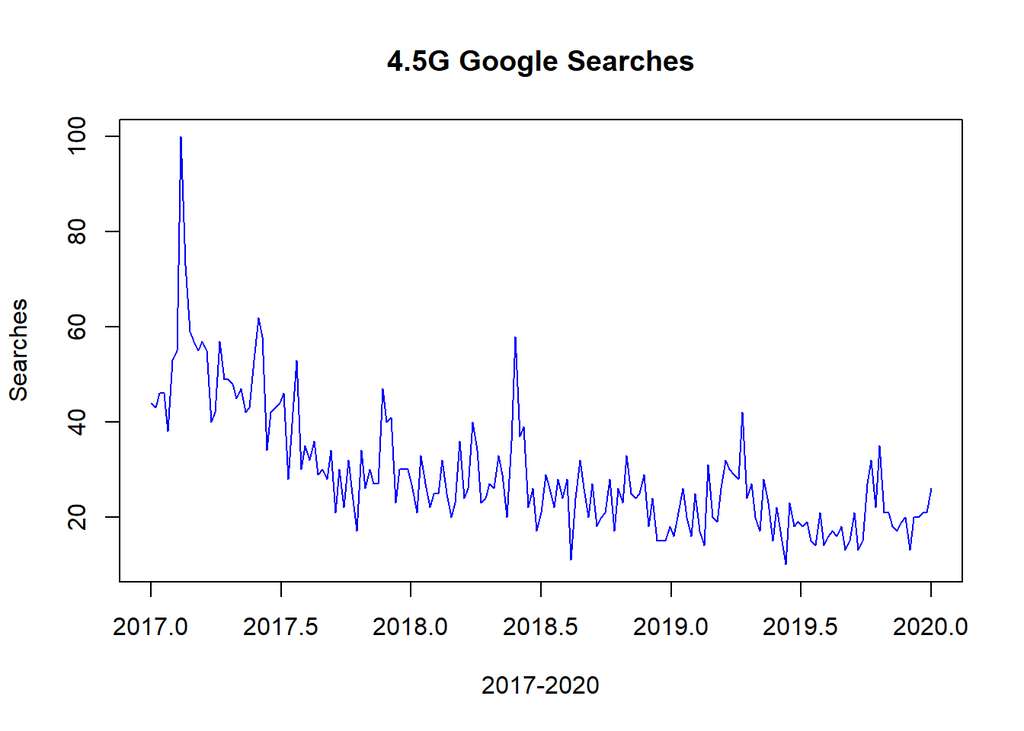

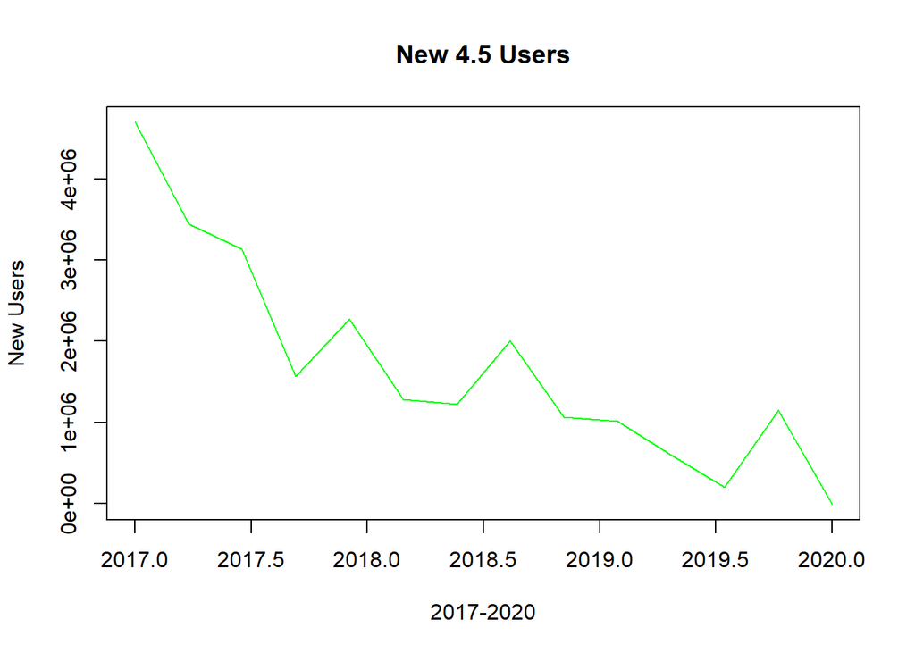

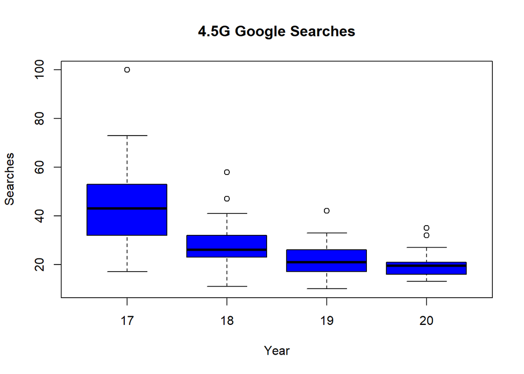

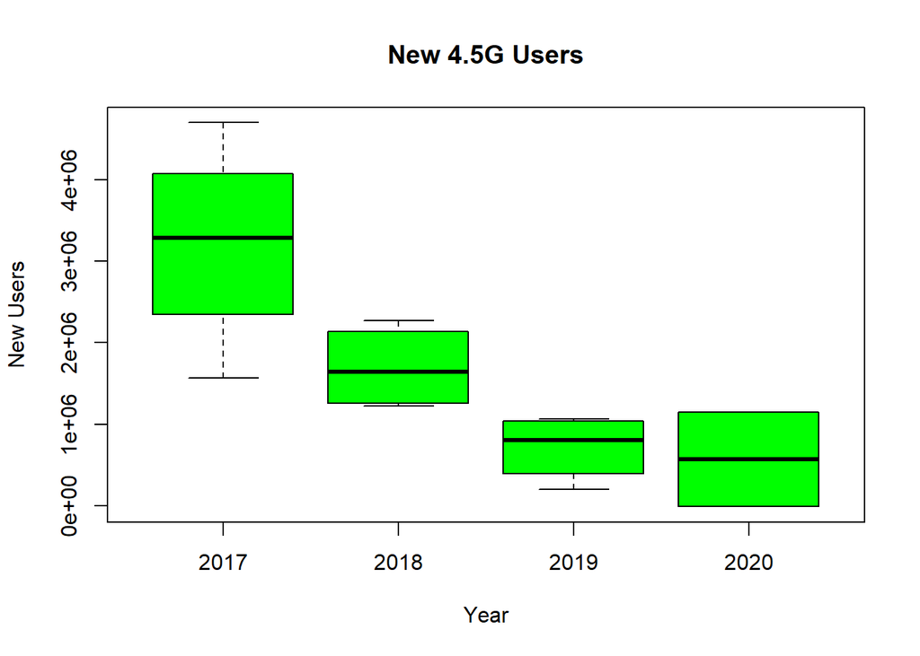

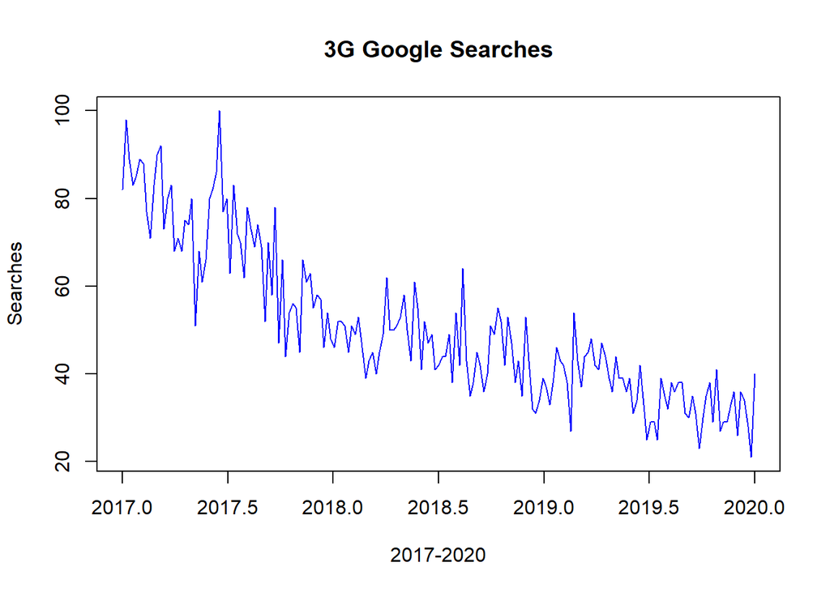

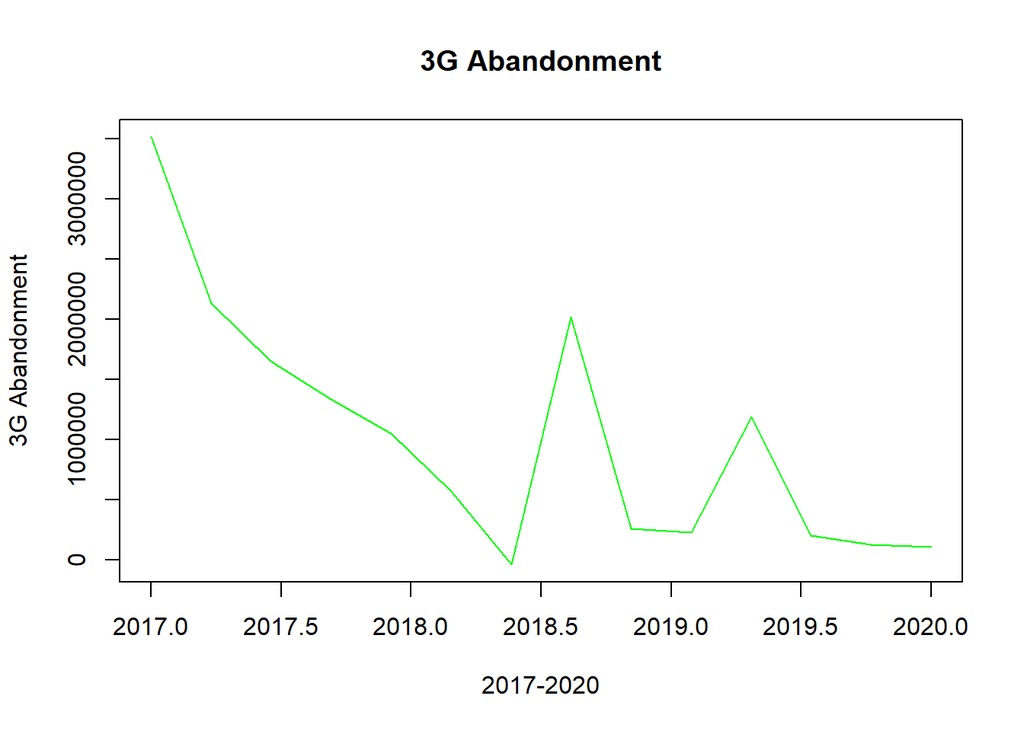

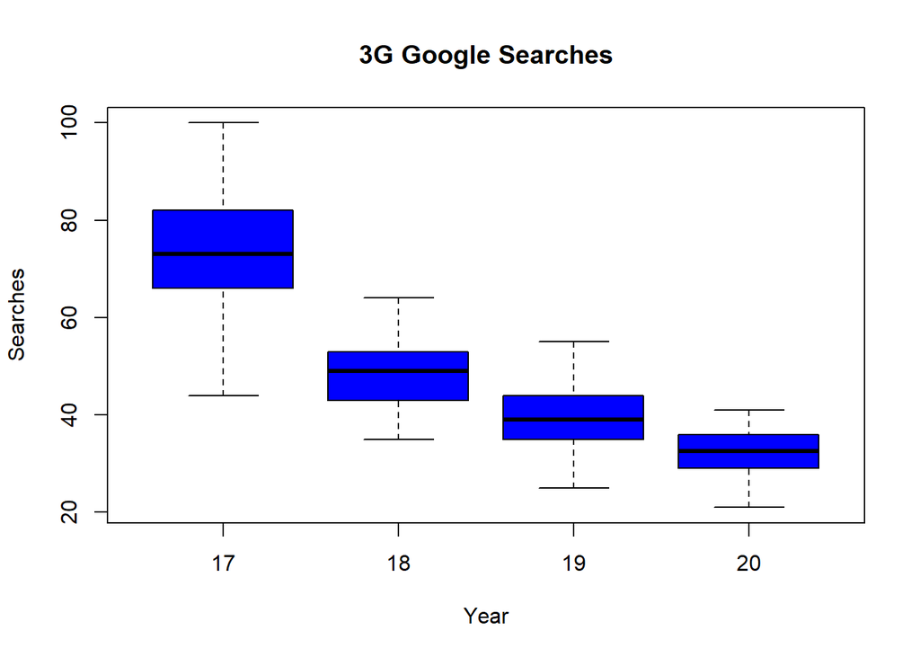

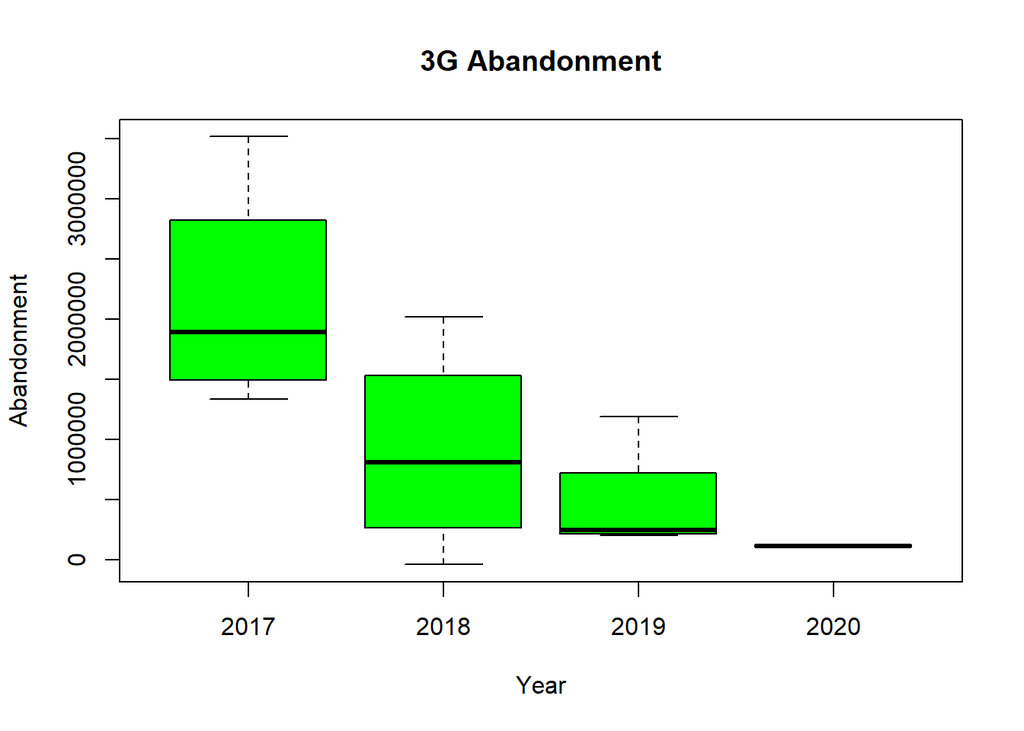

[Data](https://www.btk.gov.tr/pazar-verileri)